# Arrival Delays in Atlanta Flights

## by Micah Costello

## Investigation Overview

In my investiagation of the Atlanta Flights dataset, I wanted to see which variables could be used to predict arrival delays. In the end, I found that the variable of interest shared a noteworthy relationship with departure delays, NAS delays, and the month of the year.

I also checked arrival delays against the different airports Atlanta serves. Although most of the airports investigated did not correlate strongly with arrival delay, Los Angeles International Airport (LAX) as a destination did.

## Dataset Overview

The cleaned dataset contains information about 431,377 domestic flights to and from Atlanta, Georgia (ATL) from 1987 to 2008. During analysis, 47 datapoints with improbable values were dropped. The information about each flight includes expected and actual departure and arrival times;carrier and airplane ID data; basic flight statistics such as air time, taxi time, etc.; departure delay duration and delay types.

## Distribution of Arrival Delays

In this dataset, arrival delays range from around -60 minutes to over 800 minutes. Their distribution is unimodal, with most points clustered around zero or falling exactly on zero. Many flights arrive ahead of schedule ( negative value = early arrival), but the distribution is right-skewed with a long tail. In the visual below, we can see the entire distribution, as well as a zoomed version to see where the bulk of the data lies.

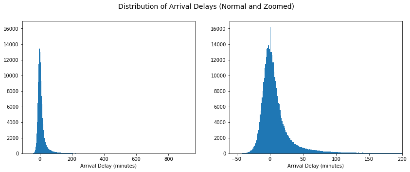

## Arrival Delays vs. Departure Delays

The variable that most strongly correlated with arrival delay is departure delay. This may seem like an obvious observation- if you leave late, you often arrive late- but it suggests that most arrival delays are at least partly caused by an event that occurs before takeoff. The two variables share a strong linear relationship.

Around where the departure delay equals 0, the linear shape breaks a bit, and we see high arrival delays matched with low departure delays.

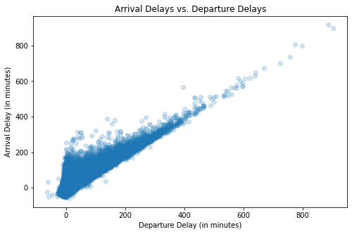

## When Departure Does Not Affect Arrival: NAS Delays

For flights where delay type is recorded, those flights with zero departure delay, as well as many flights with minimal departure delay, suffered a National Aviation System (NAS) delay.

According to the Bureau of Transportation Statistics (https://www.bts.gov/topics/airlines-and-airports/understanding-reporting-causes-flight-delays-and-cancellations accessed March 3, 2022), NAS delays can mean several different things, although non-severe weather problems represent a large percentage each year.

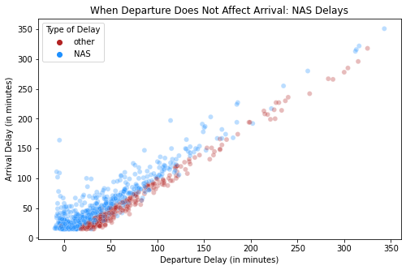

## Arrival Delay vs. Month

The month of the year has an interesting relationship with arrival delays as well. It seems logical that winter months would have increased delay times due to weather. However, the highest arrival delays tend to be in the winter *and* summer months, with lower arrival delays in spring and fall. Even so, the difference is not practically significant.

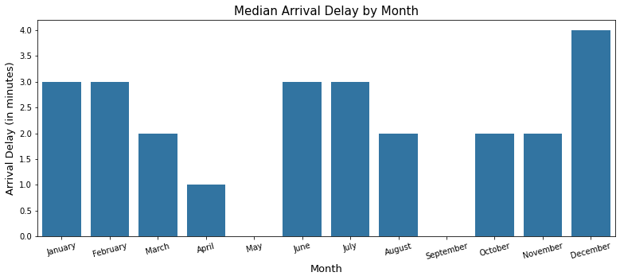

## LAX and High Arrival Delays

Finally, flights going from ATL to LAX suffered disproportionately high arrival delays compared to other destination airports with the highest delays. When checked against other variables, we can observe an interaction between LAX and time of year.

The heatmap below shows median arrival delays by season for the 10 worst destination airports in terms of delays. It reaffirms our observations about the relationship between month and arrival delay. And although the delay is always higher at LAX than at the other nine airports, the effect is drastic in the winter months.

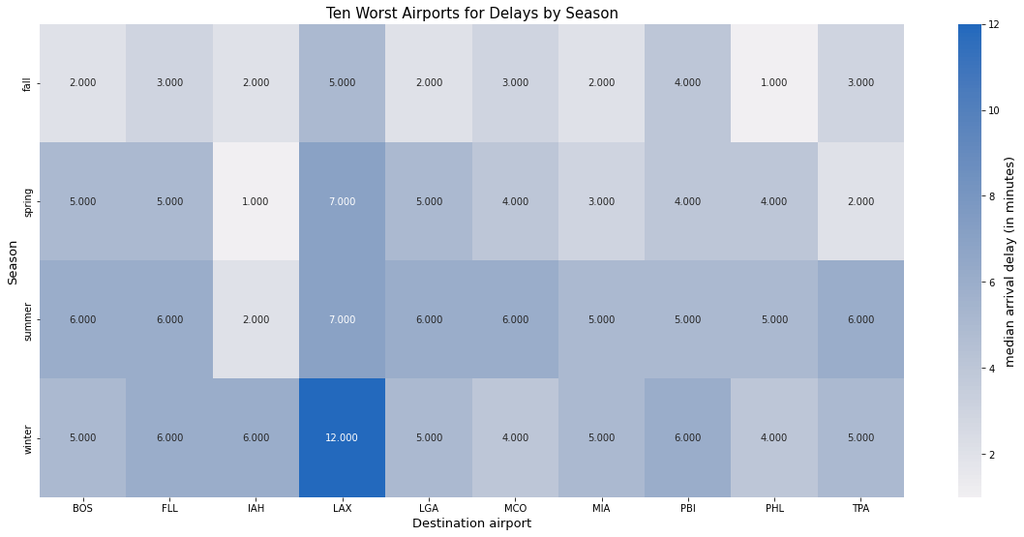

## Conclusion

To conclude, in terms of actually *predicting* arrival delays to and from Atlanta, the most accurate feature would likely be departure delays. Though month and certain airports can also indicate whether a delay will be longer or shorter.

In the absence of a departure delay, if the arrival delay is positive, an NAS delay is undoubtedly the culprit.

The good news is that the distribution of arrival delays shows us that in most cases, the arrival delay is very close to zero, and sometimes our flights actually arrive ahead of schedule.